# Rogers_CH13

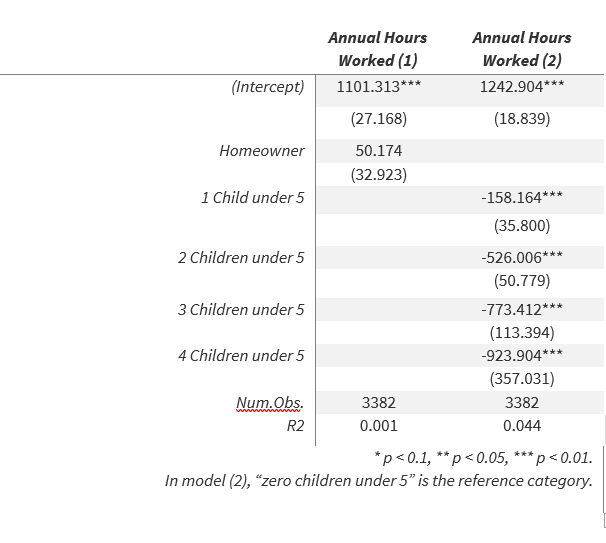

1. Interpret the coefficient on “Homeowner”
- The coefficient “Homeowner” can be interpreted as, in this sample, being a homeowner is associated with a 50 unit increase in hours worked as compared to not being a homeowner.
2. On average, how many fewer hours do people with 4 children under the age of 5 work than people with 3 children under the age of 5?
- The coefficient for 4 children is -923.904, the coefficient for 3 children is -773.412, people with 4 children under the age of five work on average 150.492 fewer hours than people with 3 children under five.
3. From this table alone can we tell whether there’s a statistically significant difference in hours worked between having 2 children and having 3? What additional test would we need to perform?

We can’t tell with the information provided by this table. According to the book, there is something called a joint F test which would be helpful here.

7. Consider the below regression table, still using the same data as in 4-6.

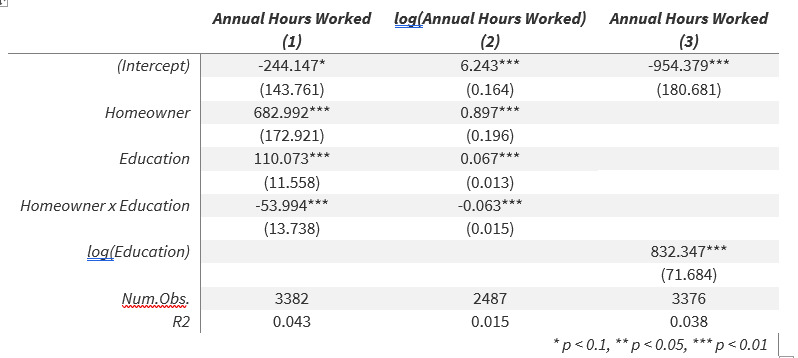

This follows the examples given in the text, where there may be underreporting or overreporting from respondents.